# Assessing the association between an eosinophil count PRS and AD case status

Thomas Battram

## 0.1 Introduction

Eosinophil counts are known to associate with eczema and thus could confound the relationship between DNAm and eczema in our EWAS of 3 eczema subtypes as part of the PACE consortium. Ideally we’d be able to estimate eosinophil counts using our DNAm data, but there are no cord blood references that include eosinophils.

There have been GWAS of blood cell counts (including eosinophils), thus we decided to assess whether the genetic component of eosinophil counts, i.e. a polygenic risk score (PRS) of eosinophil counts, associates with AD case status across our 3 subtypes. This gives an indication of whether eosinophil counts might confound the relationship between DNAm and AD.

## 0.2 Polygenic risk score generation

The latest PRS of eosinophil counts was made by Xu Y. et al. PMID: [35072137](https://pubmed.ncbi.nlm.nih.gov/35072137/). We pulled the summary statistics from this PRS (SNPs and weights) from the [PGS catalog](https://www.pgscatalog.org/publication/PGP000051/).

The PRS was generated in ALSPAC individuals using PLINKv2.0. We standardised the PRS by creating Z-scores from the PRS values. The distribution of the standardised PRS is shown in **Figure 1**.

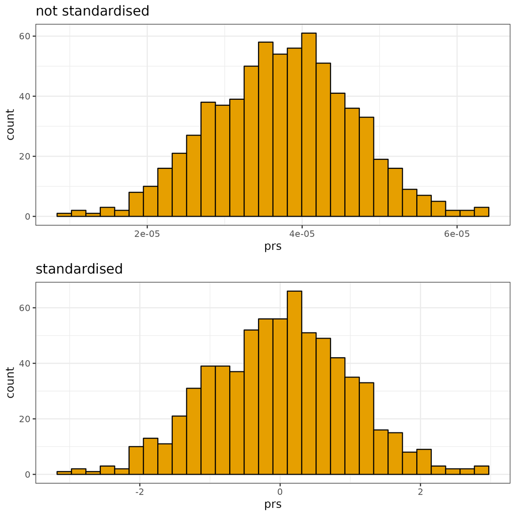

Figure 1: PRS distribution

## 0.3 Association of PRS and AD

Using logistic regression we assessed the association between the eosinophil count PRS (exposure) and AD (outcome). The results can be found in **Table 1**. The difference in PRS distribution between cases and controls is shown in **Figure 2**.

Table 1: Association between AD and an eosinophil PRS

| AD subtype | Beta (95% CI) | P |
| --- | --- | --- |
| Early-onset | 0.071 (-0.103; 0.25) | 0.4232432 |
| Childhood | 0.017 (-0.132; 0.17) | 0.8223552 |
| Persistent | 0.094 (-0.098; 0.29) | 0.3382014 |

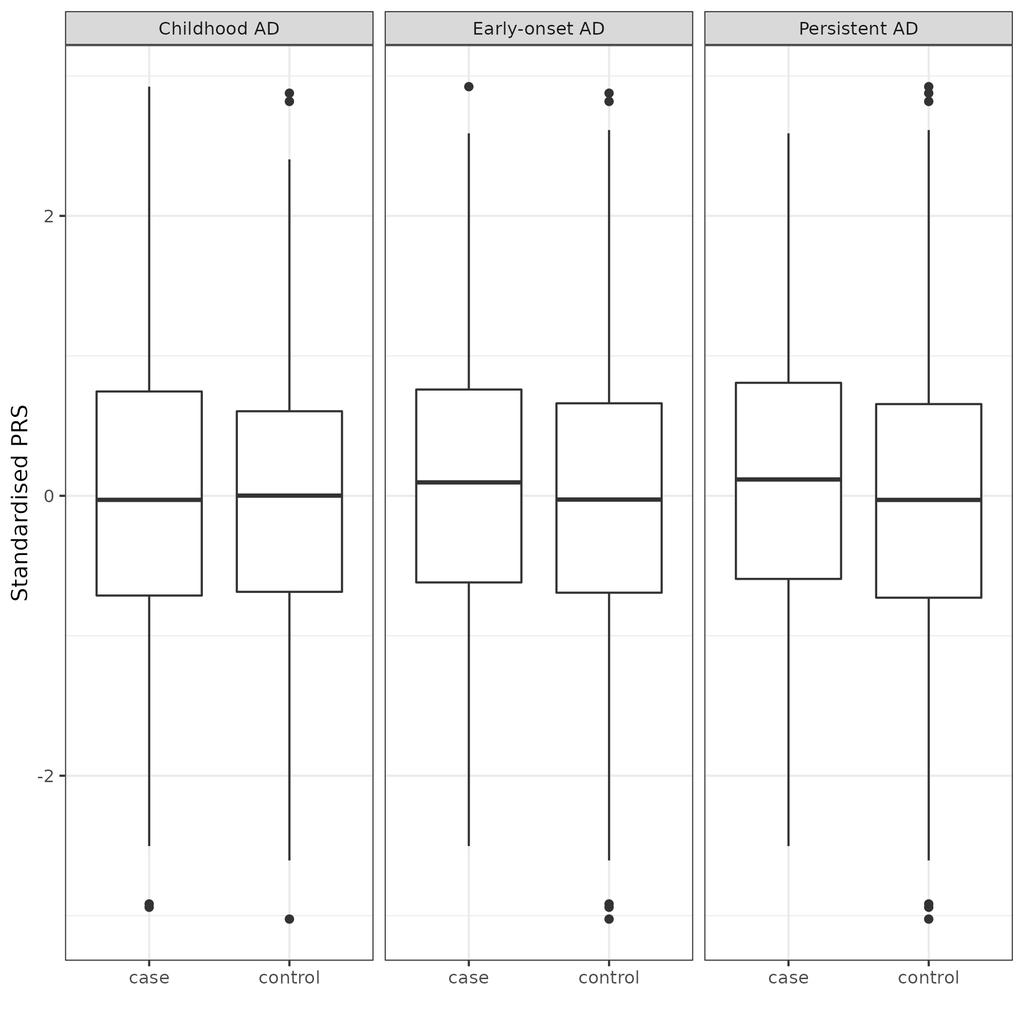

Figure 2: PRS distribution across cases and controls